# R for Reproducible Scientific Analysis

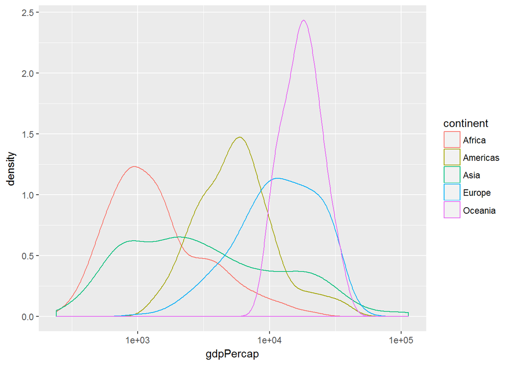

```r
# by continent
ggplot(gapminder)+
  geom_density(mapping = aes(x=gdpPercap, color=continent)) +
  scale_x_log10()
```

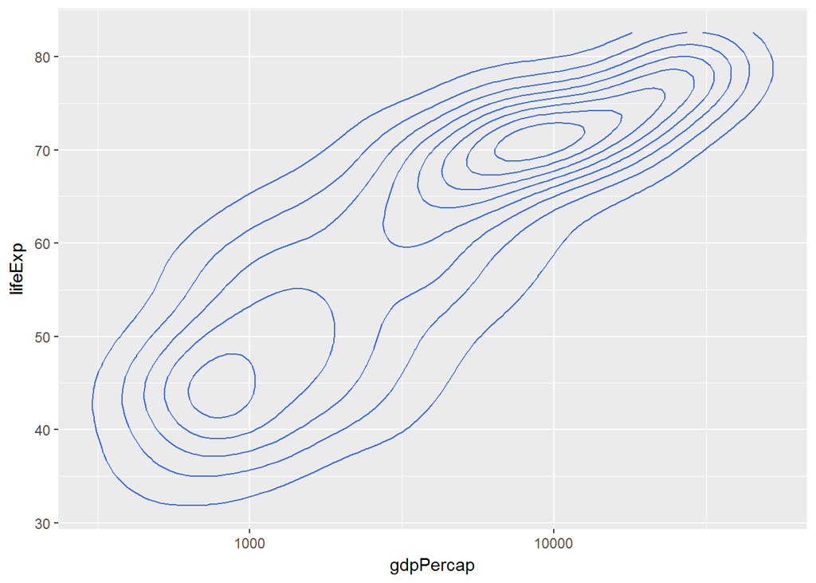

```r
## Part 3
# Density 2d
ggplot(gapminder)+
  geom_density2d(mapping = aes(x=gdpPercap, y=lifeExp)) +
  scale_x_log10()
```

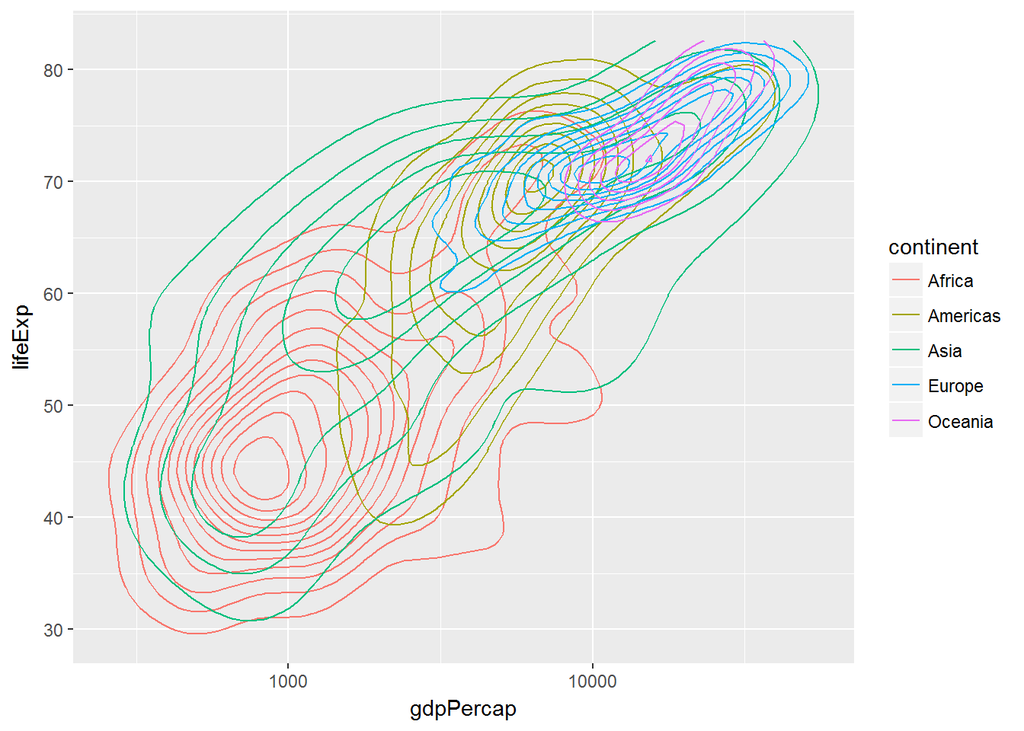

```r
# by continent
ggplot(gapminder)+
  geom_density2d(mapping = aes(x=gdpPercap, y=lifeExp, color=continent)) +
  scale_x_log10()
```

## Faceting

Multi-layered graphs employing several aesthetics can look crowded. In order to avoid it, one can split the data into different graphs using panels of similar graphs. In `ggplot2` this method is called “faceting”. Lets facet the graph above by continent and show the datapoints and the trend for each continent in a separate chart.

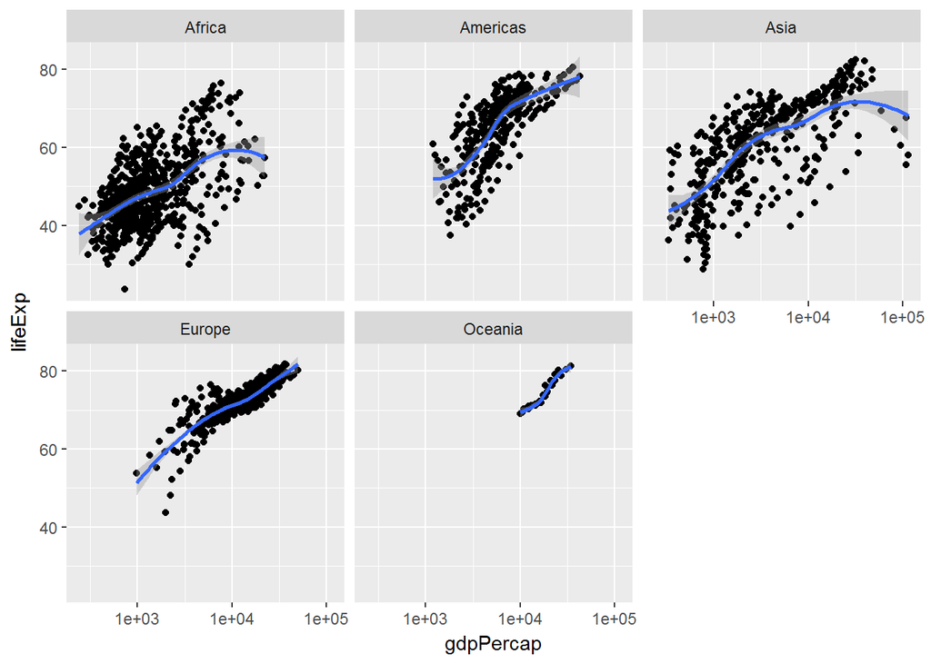

```r
ggplot(data = gapminder, mapping = aes(x = gdpPercap, y = lifeExp)) +
  geom_point() +
  geom_smooth() +
  scale_x_log10() +
  facet_wrap( ~ continent)
```

The `facet_wrap()` layer takes a “formula” as its argument, denoted by the tilde (~). This tells R to draw a panel for each unique value in the `continent` column of the `gapminder` dataset. Faceting is useful when number of panels is limited. Notice that here R places panels from left to right, “wrapping” those panels that do not fit in one row onto the new line. Learn about advanced faceting, including faceting over several variables using help on `?facet_grid()`.

Reiterating our previously proposed `ggplot2` template and adding what we learned until, now we can state:

```r
`ggplot(data = <DATA>) +
  <GEOM_FUNCTION>(mapping = aes(<MAPPINGS>)) +
  <FACET_FUNCTION>`
```

## **Challenge 7.**

### Assignment

> - Try faceting by year, keeping the linear smoother. Is there any change in slope of the linear trend over the years? What if you look at linear models per continent?

### Solution

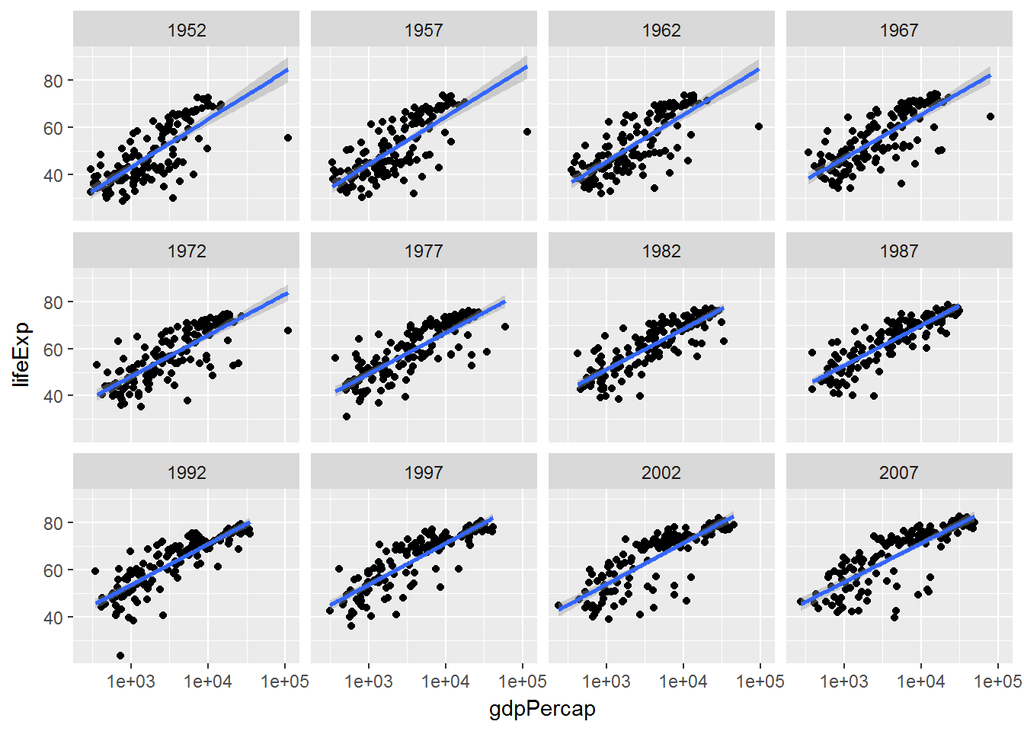

```r
# by year
ggplot(data = gapminder, mapping = aes(x = gdpPercap, y = lifeExp)) +
  geom_point() +
  geom_smooth(method = "lm") +
  scale_x_log10() +
  facet_wrap( ~ year)
```

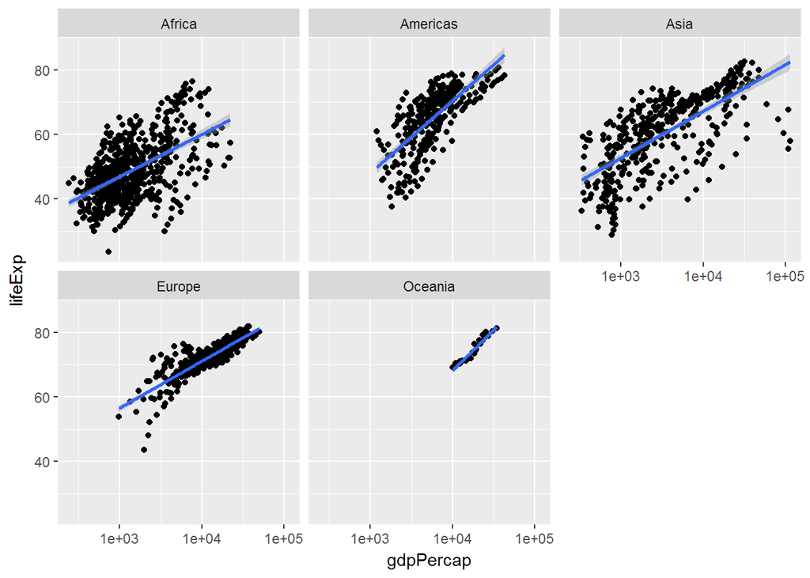

```r
# by continent
ggplot(data = gapminder, mapping = aes(x = gdpPercap, y = lifeExp)) +
  geom_point() +
  geom_smooth(method = "lm") +
  scale_x_log10() +
  facet_wrap( ~ continent)
```

## Coordinate systems

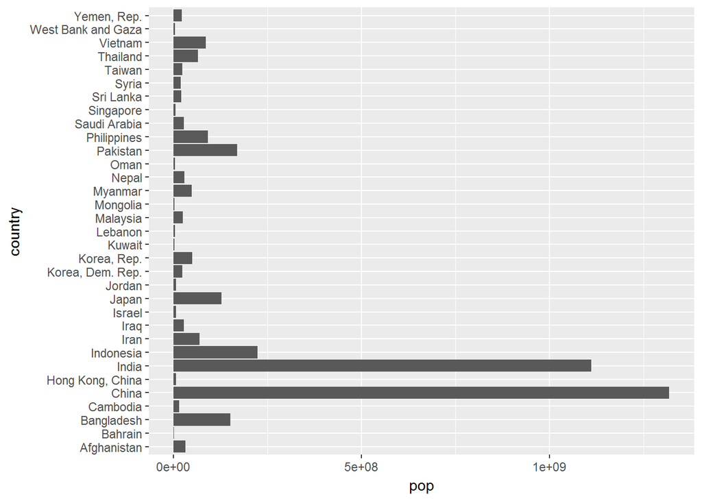

```r
ggplot(filter(gapminder, year==2007 & continent=="Asia")) +
  geom_bar(mapping = aes(x=country, y=pop), stat="identity") +
  coord_flip()
```

There are many function related to coordinate systems that allow, among other things, plotting in non-cartesian (e.g. polar and Mercator) coordinates and specifying manual limits for coordinate axis.

## Labeling the chart

Lastly we will learn how to label and annotate the chart using `labs` and `annotate` functions.

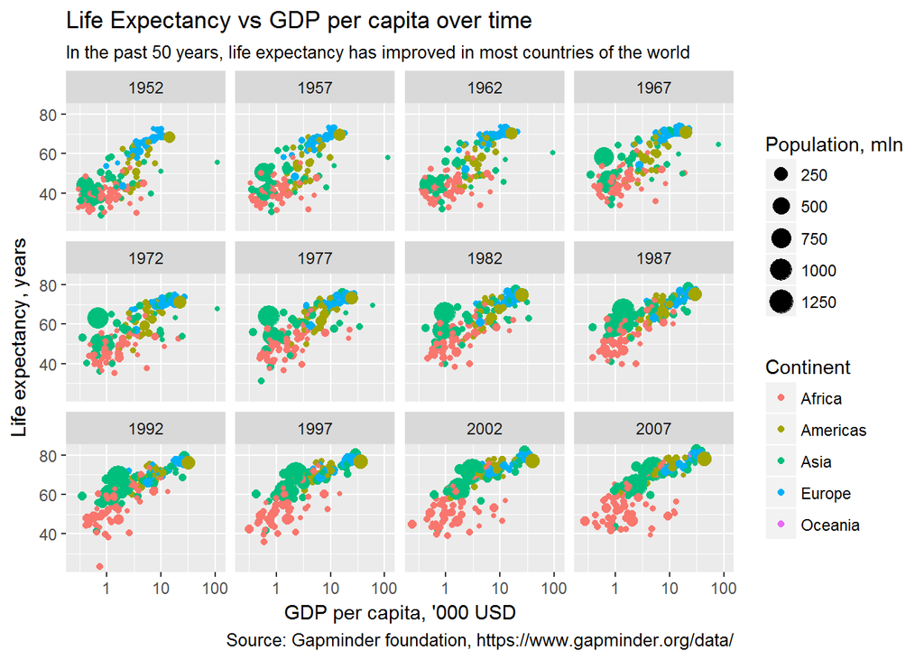

```r
ggplot(data = gapminder) +
  geom_point(mapping = aes(x = gdpPercap/10^3, y = lifeExp, size=pop/10^6, color=continent)) +
  scale_x_log10() +
  facet_wrap(~year) +
  labs(title="Life Expectancy vs GDP per capita over time",
       subtitle="In the past 50 years, life expectancy has improved in most countries of the world",
       caption="Source: Gapminder foundation, https://www.gapminder.org/data/",
       x="GDP per capita, '000 USD",
       y="Life expectancy, years",
       color="Continent",
       size="Population, mln")
```

## BONUS: Animation

The graph produced in the previous section looks quite good, but it requires a reader to follow the time aspect of the data by tracing the changes across panels. This may be better illustrated by “animating” the time dimension of the data and playing the twelve charts in front of user one after another.

```r
library(gganimate)

p <- ggplot(data = gapminder) +
  geom_point(mapping = aes(x = gdpPercap/10^3, y = lifeExp, size=pop/10^6, color=continent, frame=year)) +
  geom_text(mapping = aes(x = 40, y = 30, frame=year), label=as.character(gapminder$year), size = 16, color="grey") +
  scale_x_log10() +
  labs(title="Life Expectancy vs GDP per capita over time",
       subtitle="In the past 50 years, life expectancy has improved in most countries of the world",
       caption="Source: Gapminder foundation, https://www.gapminder.org/data/",
       x="GDP per capita, '000 USD",
       y="Life expectancy, years",
       color="Continent",
       size="Population, mln") +
  theme_bw()
gganimate(p)
```

[video not shown]

## Wrap-up

We conclude this lesson by reiterating our `ggplot2` data visualization template.

```r
`ggplot(data = <DATA>) +
  <GEOM_FUNCTION>(mapping = aes(<MAPPINGS>),
                  stat = <STAT>) +
  <SCALE_FUNCTION> +
  <COORDINATE_FUNCTION> +
  <FACET_FUNCTION> +
  <LABS>`
```

> **Still bored?**
> - Use several graphs and necessary filters to narrow down your search to those few outliers with high gdpPercap. What are those countries and in which years? What might be the reason?

> *Hint: You may want to experiment with `geom_text()` to get the country labels to show on the chart*
> - Use several graphs and necessary filters to narrow down your search to those few outliers with extraordinarily low life expectancy. What are those countries and in which years? What might be the reason?